# Prepare STIRRUPS-profile data

Michael R. McLaren

2021-07-23

STIRRUPS taxonomic profiles and associated metadata for vaginal samples were previously downloaded from the HMP DAC. This document loads and inspects this data, and prepares an abundance matrix and associated sample metadata and taxonomy table for downstream analysis.

```r
library(tidyverse)
library(here)
library(fs)
```

## Abundance matrix

The STIRRUPS profiles are in “data/stirrups-profiles”,

```r
fns <- here("data/stirrups-profiles") %>%
  dir_ls(glob = "*stirrups.profile.txt")
length(fns)
```

```
## [1] 2055
```

```r
fns[1] %>% path_file
```

```
## [1] "EP003595_K10_MV1D.stirrups.profile.txt"
```

These are TSV files. Manual inspection of the first profile (file EP003595_K10_MV1D.stirrups.profile.txt) gives some indication of the variables (columns); Lines 1 and 40 are reproduced below.

```
L1 : EP003595_K10_MV1D  Lactobacillus_crispatus_cluster AT  45958   99.0004739132308    99.6258910309223
L40: EP003595_K10_MV1D  "Lachnospiraceae"_BVAB1 AT  1   0.00215415104907156 98.8
```

The quotes in some OTU names (e.g. in L40) need to be handled carefully when reading in the files.

The [STIRRUPS Readme](https://sourceforge.net/projects/stirrups/files/) describes the variables (columns),

> Summary File:

> The summary file describes the population of the various clusters. It gives the name of the sample, the name of the taxa, the number of reads in the taxa, the percentage of reads from the sample that mapped to that taxa, and the average identity score for the taxa.

This text describes all columns except for the additional third column whose values are “AT” or “BT”. Although not documented, these appear to be abbreviations for “Above threshold” and “Below threshold” and denote whether the percent identity of the mapped reads was above a cutoff, which here seems to have been 97% (see below).

Let’s read in one file to test our ability to parse. Note the blanking of the `quote` argument to `read_tsv()` to avoid issues related to the appearance of quotes in the OTU names.

```r
cns <- c(
  'sample_name', 'species_cluster', 'threshold', 'reads', 'percent',
  'average_percent_identity'
)
x <- fns[1] %>% read_tsv(col_names = cns, col_types = 'cccddd', quote = "")
stopifnot(all.equal(x$percent, x$reads %>% {. / sum(.) * 100}))
```

Now let’s read in all files into a single data frame.

```r
x <- fns %>%
  map_dfr(read_tsv, col_names = cns, col_types = 'cccddd', quote = "")
```

Comparing the identity ranges for the above- and below- threshold reads,

```r
x %>%
  with_groups(threshold, summarize,
    across(average_percent_identity, .fns = c(min = min, max = max, n = length),
      .names = "{fn}")
  )
```

```
## # A tibble: 2 x 4
##   threshold   min   max      n
##   <chr>     <dbl> <dbl>  <int>
## 1 AT           97 100   108541
## 2 BT            0  96.9  43022
```

confirms that 97% identity was used as the threshold. For our analysis, we will use only only the above-threshold reads.

Next, let’s prepare an abundance matrix for downstream use, using just the above-threshold reads, putting OTUs as columns, and sorting samples and OTUs lexicographically. The lexicographic sorting will put the OTUs with quoted first parts first in the matrix.

```r
mat <- x %>%
  filter(threshold == "AT") %>%
  select(sample_name, species_cluster, reads) %>%
  pivot_wider(names_from = species_cluster,
    values_from = reads, values_fill = 0,
    names_sort = TRUE
  ) %>%
  arrange(sample_name) %>% # should be redundant
  column_to_rownames(var = "sample_name") %>%
  as("matrix")

mat[1:2, 1:2]
```

```
##                   "Clostridiaceae_1"_OTU17 "Lachnospiraceae"_BVAB1
## EP003595_K10_MV1D                        0                       1
## EP004835_K10_MV1D                        0                   58587
```

```r
colSums(mat) %>% summary
```

```
##     Min.  1st Qu.   Median     Mean  3rd Qu.     Max.
##        1      408     4269   356504    32172 42095155
```

```r
mean(mat > 0)
```

```
## [1] 0.1467167
```

```r
mean(mat == 0)
```

```
## [1] 0.8532833
```

```r
rm(x)
```

## Sample data

Sample (meta)data is available through the metadata associated with the file manifest from the HMP DAC, as well as in the table I previously parsed from the BioSample and ENA metadata. Let’s first load and inspect the manifest metadata.

```r
fns <- here("data/stirrups-profiles") %>% dir_ls(glob = "*manifest*")
fns %>% path_file
```

```
## [1] "hmp_manifest_4abcc24e0d.tsv"          "hmp_manifest_metadata_6f44f20b39.tsv"
```

```r
l <- fns %>%
  map(read_tsv)
stopifnot(identical(
    l[[1]] %>% pull(sample_id),
    l[[2]] %>% pull(sample_id)
))
```

The first file is information about the files; the second is information about the samples. The rows correspond to each other but can also be matched using the `sample_id` field.

```r
hmpsam <- left_join(l[[1]], l[[2]], by = "sample_id")
hmpsam %>% glimpse
```

```
## Rows: 2,055
## Columns: 13
## $ file_id          <chr> "e4fdfd770c4102d4032c2ca5ca3e0768", "e4fdfd770c4102d403…
## $ md5              <chr> "54e63d7c473cbc20253d2a6a412122e2", "1cca6df92c79fcb985…
## $ size             <dbl> 14111, 2080, 4074, 4458, 1911, 7973, 2552, 4599, 5032, …
## $ urls             <chr> "https://downloads.hmpdacc.org/ihmp/ptb/genome/microbio…
## $ sample_id        <chr> "76612bd9a41885add4f6b0b768d54740", "e50d0c183689e4053c…
## $ subject_id       <chr> "EP956934", "EP445627", "EP094101", "EP824738", "EP7407…
## $ subject_uuid     <chr> "e50d0c183689e4053ccb35f8b2a0fb6d", "88af6472fb03642dd5…
## $ sample_body_site <chr> "vagina", "vagina", "vagina", "vagina", "vagina", "vagi…
## $ visit_number     <dbl> 3, 4, 1, 6, 5, 3, 1, 2, 3, 3, 1, 1, 5, 3, 1, 6, 4, 1, 1…
## $ subject_gender   <chr> "female", "female", "female", "female", "female", "fema…
## $ subject_race     <chr> "None", "unknown", "None", "unknown", "None", "None", "…
## $ study_full_name  <chr> "momspi", "momspi", "momspi", "momspi", "momspi", "moms…
## $ project_name     <chr> "Integrative Human Microbiome Project", "Integrative Hu…
```

To match these rows with the rows in the abundance matrix, we can extract the sample name from the file name at the end of the URLs,

```r
hmpsam1 <- hmpsam %>%
  mutate(
    file = path_file(urls),
    sample_name = str_extract(file, "^[^\\.]+")
  ) %>%
  relocate(sample_name) %>%
  relocate(starts_with("file"), md5, size, urls, .after = last_col()) %>%
  glimpse
```

```
## Rows: 2,055
## Columns: 15
## $ sample_name      <chr> "EP956934_K30_MV1D", "EP445627_K40_MV1D", "EP094101_K10…
## $ sample_id        <chr> "76612bd9a41885add4f6b0b768d54740", "e50d0c183689e4053c…
## $ subject_id       <chr> "EP956934", "EP445627", "EP094101", "EP824738", "EP7407…
## $ subject_uuid     <chr> "e50d0c183689e4053ccb35f8b2a0fb6d", "88af6472fb03642dd5…
## $ sample_body_site <chr> "vagina", "vagina", "vagina", "vagina", "vagina", "vagi…
## $ visit_number     <dbl> 3, 4, 1, 6, 5, 3, 1, 2, 3, 3, 1, 1, 5, 3, 1, 6, 4, 1, 1…
## $ subject_gender   <chr> "female", "female", "female", "female", "female", "fema…
## $ subject_race     <chr> "None", "unknown", "None", "unknown", "None", "None", "…
## $ study_full_name  <chr> "momspi", "momspi", "momspi", "momspi", "momspi", "moms…
## $ project_name     <chr> "Integrative Human Microbiome Project", "Integrative Hu…
## $ file_id          <chr> "e4fdfd770c4102d4032c2ca5ca3e0768", "e4fdfd770c4102d403…
## $ file             <chr> "EP956934_K30_MV1D.stirrups.profile.txt", "EP445627_K40…
## $ md5              <chr> "54e63d7c473cbc20253d2a6a412122e2", "1cca6df92c79fcb985…
## $ size             <dbl> 14111, 2080, 4074, 4458, 1911, 7973, 2552, 4599, 5032, …
## $ urls             <chr> "https://downloads.hmpdacc.org/ihmp/ptb/genome/microbio…
```

```r
hmpsam1 %>% select(file, sample_name) %>% head(2)
```

```
## # A tibble: 2 x 2
##   file                                   sample_name
##   <chr>                                  <chr>
## 1 EP956934_K30_MV1D.stirrups.profile.txt EP956934_K30_MV1D
## 2 EP445627_K40_MV1D.stirrups.profile.txt EP445627_K40_MV1D
```

Check that these names match the matrix

```r
stopifnot(setequal(hmpsam1$sample_name, rownames(mat)))
```

Now let’s pull in the SRA/BioSample metadata

```r
biosam <- here("output/sample-data", "sample-data.csv.bz2") %>% read_csv %>%
  glimpse
```

```
## Rows: 9,203
## Columns: 40
## $ sample_accession           <chr> "SAMN08511318", "SAMN08511317", "SAMN08511316…
## $ study_accession            <chr> "PRJNA326441", "PRJNA326441", "PRJNA326441", …
## $ secondary_study_accession  <chr> "SRP132490", "SRP132490", "SRP132490", "SRP13…
## $ secondary_sample_accession <chr> "SRS2985222", "SRS2985220", "SRS2985221", "SR…
## $ experiment_accession       <chr> "SRX3727997", "SRX3727993", "SRX3727994", "SR…
## $ run_accession              <chr> "SRR6755365", "SRR6755369", "SRR6755368", "SR…
## $ submission_accession       <chr> "SRA657805", "SRA657805", "SRA657805", "SRA65…
## $ sample_name                <chr> "EP639218_K10_MV1D", "EP247445_K130_BRCD", "E…
## $ sample_id                  <chr> "8938ac880f194a32bc6b736c156ec674", "8938ac88…
## $ sample_description         <chr> "This sample has been submitted by pda|jgeorg…
## $ description                <chr> "Illumina MiSeq sequencing; 16S rRNA sequenci…
## $ host                       <chr> "Homo sapiens", "Homo sapiens", "Homo sapiens…
## $ host_sex                   <chr> "female", "female", "female", "female", "fema…
```

[output cut: 27 more lines]

```r
biosam %>% count(host_body_product, host_body_site)
```

```
## # A tibble: 6 x 3
##   host_body_product host_body_site                      n
##   <chr>             <chr>                           <int>
## 1 buccal mucosa     saliva [UBERON:0001836]          3347
## 2 cervix of uterus  cervical mucus [UBERON:0012248]   162
## 3 rectal            rectum                           2705
## 4 stool             feces [UBERON:0001988]            774
## 5 unknown           unknown                           155
## 6 vaginal           vaginal mucosa [UBERON:0004983]  2060
```

```r
biosam %>% filter(host_body_product == "vaginal") %>% count(center_name)
```

```
## # A tibble: 18 x 2
##    center_name     n
##    <chr>       <int>
##  1 SUB3611280    122
##  2 SUB3628501    118
##  3 SUB3628984    140
##  4 SUB3628985    124
##  5 SUB3629001    128
##  6 SUB3629119    129
##  7 SUB3629123    124
##  8 SUB3629124    158
##  9 SUB3629141    114
## 10 SUB3629142    109
## 11 SUB3629242    107
## 12 SUB3629639     91
## 13 SUB3629749    106
## 14 SUB3629994    105
## 15 SUB3629996     76
## 16 SUB3629999     98
## 17 SUB3630003    129
## 18 SUB3630009     82
```

```r
biosam %>% filter(host_body_product == "vaginal") %>% count(instrument_model)
```

```
## # A tibble: 1 x 2
##   instrument_model     n
##   <chr>            <int>
## 1 Illumina MiSeq    2060
```

We don’t gain much of interest from this larger set of metadata for the analyses we will be doing, other than perhaps “center_name”.

Let’s use a paired-down version of the BioSample metadata, after checking that the two tables are consistent.

```r
setdiff(hmpsam1$sample_name, biosam$sample_name)
```

```
## character(0)
```

```r
biosam %>%
  filter(host_body_product == "vaginal") %>%
  pull(sample_name) %>%
  setdiff(hmpsam1$sample_name)
```

```
## [1] "EP070043_K40_MV1D" "EP070043_K20_MV1D" "EP994895_K50_MV1D"
## [4] "EP750568_K20_MV1D" "EP028055_K20_MV1D"
```

```r
tmp <- left_join(hmpsam1, biosam, by = "sample_name")
all.equal(tmp$host_visit_number, tmp$visit_number)
```

```
## [1] TRUE
```

```r
all.equal(tmp$host_subject_id, tmp$host_subject_id)
```

```
## [1] TRUE
```

(There are a couple vaginal samples that are missing from the HMP data)

```r
sam <- biosam %>%
  filter(sample_name %in% hmpsam1$sample_name) %>%
  select(sample_name, starts_with("host"), center_name, -host_tax_id) %>%
  arrange(sample_name)
stopifnot(identical(sam$sample_name, rownames(mat)))
```

## Taxonomy

```r
colnames(mat) %>% head
```

```
## [1] "\"Clostridiaceae_1\"_OTU17"    "\"Lachnospiraceae\"_BVAB1"
## [3] "\"Lachnospiraceae\"_OTU33"     "\"Porphyromonadaceae\"_OTU134"
## [5] "\"Prevotellaceae\"_OTU61"      "\"Proteobacteria\"_OTU-T1"
```

```r
colnames(mat) %>% tail
```

```
## [1] "Varibaculum_cambriense"       "Veillonella_cluster61"
## [3] "Veillonella_montpellierensis" "Veillonella_ratti"
## [5] "Weeksella_virosa"             "Weissella_cibaria"
```

We can parse the genus from the OTU name for the OTU names without quotes.

```r
otu_genus <- tibble(otu = colnames(mat)) %>%
  mutate(
    genus = str_extract(otu, "^[^_]+"),
    genus = ifelse(str_detect(genus, "^\""), NA, genus)
  ) %>%
  print
```

```
## # A tibble: 360 x 2
##    otu                                genus
##    <chr>                              <chr>
##  1 "\"Clostridiaceae_1\"_OTU17"       <NA>
##  2 "\"Lachnospiraceae\"_BVAB1"        <NA>
##  3 "\"Lachnospiraceae\"_OTU33"        <NA>
##  4 "\"Porphyromonadaceae\"_OTU134"    <NA>
##  5 "\"Prevotellaceae\"_OTU61"         <NA>
##  6 "\"Proteobacteria\"_OTU-T1"        <NA>
##  7 "Abiotrophia_defectiva"            Abiotrophia
##  8 "Acidaminococcus_fermentans"       Acidaminococcus
##  9 "Acidovorax_delafieldii_temperans" Acidovorax
## 10 "Acinetobacter_baumanii"           Acinetobacter
## # … with 350 more rows
```

I’m not sure what database files were used; however, we can download the (perhaps outdated) taxonomy table from the Sourceforge page,

```r
base_url <- "https://sourceforge.net/projects/stirrups/files"
fns <- c("taxidfile.txt", "taxon_hierarchy.txt")
urls <- file.path(base_url, fns) # path() will mangle the url
dests <- here("data/stirrups-database", fns)
if (!file_exists(dests[1])) {
  walk2(urls, dests, download.file, method = "wget")
}
dests[2] %>% read_lines(n_max = 2)
```

```
## [1] "Nanoarchaeum\tgenus\t0\tsubfamily\t0\tfamily\t0\tsuborder\t0\torder\t0\tsubclass\t0\tclass\tNanoarchaeota\tphylum\tArchaea\tdomain\tRoot\tno rank\t\t\t\t\t\t\t\t"
## [2] "Procabacter\tgenus\t0\tsubfamily\tProcabacteriaceae\tfamily\t0\tsuborder\tProcabacteriales\torder\t0\tsubclass\tBetaproteobacteria\tclass\tProteobacteria\tphylum\tBacteria\tdomain\tRoot\tno rank\t\t\t\t\t\t\t\t"
```

```r
x <- dests[2] %>%
  read_tsv(col_names = FALSE) %>%
  select(!where(~all(is.na(.))))
```

Looks like the format is alternating columns of value, name. Let’s parse a standard taxonomy table from this.

```r
cns <- str_c(sep = "_",
  rep(c("value", "rank"), times = 10),
  rep(1:10, each = 2)
)
x1 <- x %>% set_names(cns) %>% mutate(idx = row_number())
x2 <- x1 %>%
  pivot_longer(
    -idx,
    names_to = c(".value", "rank_idx"),
    names_sep = "_"
  )
```

Note, there are duplicates for a few taxa in rank “suborder”.

```r
dups <- x2 %>%
  add_count(idx, rank) %>%
  filter(n > 1) %>%
  print
```

```
## # A tibble: 36 x 5
##      idx rank_idx value            rank         n
##    <int> <chr>    <chr>            <chr>    <int>
##  1   128 3        Cystobacterineae suborder     2
##  2   128 4        0                suborder     2
##  3   162 3        Cystobacterineae suborder     2
##  4   162 4        0                suborder     2
##  5   253 3        Sorangiineae     suborder     2
##  6   253 4        0                suborder     2
##  7   317 3        Sorangiineae     suborder     2
##  8   317 4        0                suborder     2
##  9   346 3        Cystobacterineae suborder     2
## 10   346 4        0                suborder     2
## # … with 26 more rows
```

```r
dups %>% count(rank)
```

```
## # A tibble: 1 x 2
##   rank         n
##   <chr>    <int>
## 1 suborder    36
```

```r
x2 %>% filter(idx == 128)
```

```
## # A tibble: 10 x 4
##      idx rank_idx value             rank
##    <int> <chr>    <chr>             <chr>
##  1   128 1        Anaeromyxobacter  genus
##  2   128 2        Cystobacteraceae  family
##  3   128 3        Cystobacterineae  suborder
##  4   128 4        0                 suborder
##  5   128 5        Myxococcales      order
##  6   128 6        0                 subclass
##  7   128 7        Deltaproteobacter class
##  8   128 8        Proteobacteria    phylum
##  9   128 9        Bacteria          domain
## 10   128 10       Root              no rank
```

We can fix by just subsetting to the ranks we are actually interested in before pivoting wide.

```r
rnks <- c("genus", "family", "order", "class", "phylum", "domain") %>% rev
x3 <- x2 %>%
  mutate(value = ifelse(value == "0", NA_character_, value)) %>%
  filter(rank %in% rnks) %>%
  select(-rank_idx) %>%
  pivot_wider(names_from = rank, values_from = value) %>%
  select(all_of(rnks))
```

How many of our OTUs’ genera appear in this table?

```r
genera <- otu_genus %>% filter(!is.na(genus)) %>% pull(genus)
table(genera %in% x3$genus)
```

```
##
## FALSE  TRUE
##    24   330
```

Most, but not all, suggesting that this is not the actual reference set that was used for these STIRRUPS profiles.

Let’s join by genus with our OTUs into a tax table,

```r
tax <- otu_genus %>%
  left_join(x3, by = "genus") %>%
  relocate(genus, .after = last_col())
```

## Reference sequences

We can similarly download the database in the SourceForge project (https://sourceforge.net/projects/stirrups/files/), but this may not be the database that was actually used.

```r
ref_url <- "https://sourceforge.net/projects/stirrups/files/vaginal_16S_V1V3_refdb1-1.fa"
ref_file <- path_file(ref_url)
ref_dest <- here("data/stirrups-database", ref_file)
ref_dest %>% path_dir %>% dir_create
if (!file_exists(ref_dest)) {
  download.file(ref_url, ref_dest, method = "wget")
}
```

```r
refs <- Biostrings::readDNAStringSet(ref_dest)
nms <- refs %>% names
nms %>% head(2)
```

```
## [1] "gi|173695|gb|M59083.1|genus|Acetitomaculum|species|ruminis|strain|Acetomaculum ruminis|start|31|end|509|length|479|details|AETRR16S/31-509 Acetomaculum ruminis 16S ribosomal RNA"
## [2] "gi|6456800|emb|AJ234039.1|genus|Actinomyces|species|bowdenii|strain|Actinomyces bowdenii strain M1956_95_1|start|1|end|496|length|496|details|Actinomyces bowdenii strain M1956_95_1 16S rRNA gene, strain M1956/95/1"
```

Next, we need to build the names of the species clusters in the STIRRUPS output from these names. Perhaps the STIRRUPS names come from joining the genus and species fields in the sequence names.

```r
colnames(mat) %>% str_subset("Acetomaculum")
```

```
## character(0)
```

```r
colnames(mat) %>% str_subset("Actinomyces")
```

```
##  [1] "Actinomyces_cardiffensis"           "Actinomyces_dentalis"
##  [3] "Actinomyces_europaeus"              "Actinomyces_hongkongensis"
##  [5] "Actinomyces_johnsonii"              "Actinomyces_massiliensis"
##  [7] "Actinomyces_meyeri_odontolyticus"   "Actinomyces_naeslundii"
##  [9] "Actinomyces_nasicola"               "Actinomyces_neuii"
## [11] "Actinomyces_oris"                   "Actinomyces_radingae"
## [13] "Actinomyces_timonensis_denticolens" "Actinomyces_turicensis"
## [15] "Actinomyces_urogenitalis"           "Actinomyces_viscosus"
```

What about the OTUs whose names have quoted family names?

```r
nms %>% str_subset("Clostridiaceae")
```

```
## [1] "gi|163813844|ref|NZ_ABEZ02000021.1|genus|Clostridiaceae|species|cluster18|strain|Clostridium bartlettii|start|1|end|0|length|0|details|:84162-85652  16S C_bartlettii-2.0.1_Cont619, whole genome shotgun sequence"
## [2] "gi|17529652|dbj|AB075769.1|genus|Clostridiaceae|species|cluster18|strain|Clostridium bifermentans strain ATCC_638|start|1|end|450|length|450|details|Clostridium bifermentans strain ATCC_638 16S rRNA, partial sequence, strain: ATCC 638"
## [3] "gi|437750|emb|X73451.1|genus|Clostridiaceae|species|cluster18|strain|Clostridium ghonii strain NCIMB 10636|start|1|end|453|length|453|details|Clostridium ghonii strain NCIMB 10636 16S rRNA gene, strain NCIMB 10636"
## [4] "gi|17529654|dbj|AB075771.1|genus|Clostridiaceae|species|cluster18|strain|Clostridium sordellii strain ATCC 9714|start|1|end|444|length|444|details|Clostridium sordellii strain ATCC 9714 16S rRNA, partial sequence, strain: ATCC 9714"
## [5] "gi|315466290|emb|FR749985.1|genus|Clostridiaceae|species|cluster18|strain|Eubacterium tenue strain DSM 20695T|start|18|end|467|length|450|details|Eubacterium tenue partial 16S rRNA gene, type strain DSM 20695T, clone 2"
```

```r
nms %>% str_subset("Lachnospiraceae")
```

```
## [1] "gi|125630736|gb|EF382648.1|genus|\"Lachnospiraceae\"|species|Cellulosilyticum ruminicola|strain|Cellulosilyticum ruminicola strain H1|start|59|end|526|length|468|details|/59-526 Cellulosilyticum ruminicola strain H1 16S ribosomal RNA gene, partial sequence"
## [2] "gi|51512126|gb|AY699277.1|genus|\"Lachnospiraceae\"|species|Lachnospira pectinoschiza|strain|Lachnospira pectinoschiza isolate M81|start|21|end|500|length|480|details|/21-500 Lachnospira pectinoschiza isolate M81 16S ribosomal RNA gene, partial sequence"
## [3] "gi|238278443|gb|GQ046543.1|genus|\"Lachnospiraceae\"|species|BVAB1|strain|Lachnospiraceae BVAB1|start|8|end|489|length|480|details|/1-480 Uncultured BVAB1 clone nbw1001d02c1 16S ribosomal RNA gene, partial sequence (BVAB1)"
```

```r
nms %>% str_subset("Porphyromonadaceae")
```

```
## character(0)
```

From this quick look, it seems like the cases where the species name in the STIRRUPS output is of the form “OTU#” are not in the database, and perhaps are de novo OTUs, and the other cases are in the database.

Let’s drop this for now.

## Explore data

For this part, I will first load the data into a phyloseq object

```r
library(speedyseq)
ps <- phyloseq(
  otu_table(mat, FALSE),
  sample_data(sam),
  tax_table(tax)
)
```

```
## Assuming first column, `sample_name`, contains the sample names
```

```
## Assuming first column, `otu`, contains the taxa names
```

```r
stopifnot(setequal(rownames(mat), sample_names(ps)))
# stopifnot(setequal(colnames(mat), taxa_names(ps)))
setdiff(colnames(mat), taxa_names(ps))
```

```
## [1] "\"Clostridiaceae_1\"_OTU17"    "\"Lachnospiraceae\"_BVAB1"
## [3] "\"Lachnospiraceae\"_OTU33"     "\"Porphyromonadaceae\"_OTU134"
## [5] "\"Prevotellaceae\"_OTU61"      "\"Proteobacteria\"_OTU-T1"
```

```r
setdiff(taxa_names(ps), colnames(mat))
```

```
## [1] "Clostridiaceae_1_OTU17"    "Lachnospiraceae_BVAB1"
## [3] "Lachnospiraceae_OTU33"     "Porphyromonadaceae_OTU134"
## [5] "Prevotellaceae_OTU61"      "Proteobacteria_OTU-T1"
```

Note, phyloseq apparently doesn’t allow quotes in the taxa names and has automatically removed them.

Next we will look for the presence of OTUs corresponding to the 7 species from @brooks2015thet.

```r
taxa_names(ps) %>% str_subset("Lactobacillus_crispatus")
```

```
## [1] "Lactobacillus_crispatus_cluster" "Lactobacillus_crispatus_type1"
```

```r
taxa_names(ps) %>% str_subset("Lactobacillus_iners")
```

```
## [1] "Lactobacillus_iners"
```

```r
taxa_names(ps) %>% str_subset("Gardnerella")
```

```
## [1] "Gardnerella_vaginalis"
```

```r
taxa_names(ps) %>% str_subset("Atopobium")
```

```
## [1] "Atopobium_minutum"           "Atopobium_OTU7"
## [3] "Atopobium_parvulum"          "Atopobium_rimae"
## [5] "Atopobium_sp_oral_taxon_810" "Atopobium_vaginae"
```

```r
taxa_names(ps) %>% str_subset("Streptococcus")
```

```
##  [1] "Streptococcus_agalactiae"
##  [2] "Streptococcus_anginosus"
##  [3] "Streptococcus_cluster21"
##  [4] "Streptococcus_cluster29"
##  [5] "Streptococcus_dentirousetti"
##  [6] "Streptococcus_dysgalactiae"
##  [7] "Streptococcus_gordonii"
##  [8] "Streptococcus_intermedius_constellatus"
##  [9] "Streptococcus_massiliensis"
## [10] "Streptococcus_mutans"
## [11] "Streptococcus_parasanguinis"
## [12] "Streptococcus_pseudoporcinus"
## [13] "Streptococcus_salivarius_thermophilus_vestibularis"
## [14] "Streptococcus_sobrinus"
```

```r
taxa_names(ps) %>% str_subset("Sneathia")
```

```
## [1] "Sneathia_amnii"        "Sneathia_OTU65"        "Sneathia_sanguinegens"
```

```r
taxa_names(ps) %>% str_subset("Prevotella")
```

```
##  [1] "Prevotellaceae_OTU61"              "Prevotella_amnii"
##  [3] "Prevotella_baroniae"               "Prevotella_bergensis"
##  [5] "Prevotella_bivia"                  "Prevotella_buccae"
##  [7] "Prevotella_cluster2"               "Prevotella_cluster50"
##  [9] "Prevotella_copri"                  "Prevotella_corporis"
## [11] "Prevotella_dentalis"               "Prevotella_denticola"
## [13] "Prevotella_disiens"                "Prevotella_enoeca"
## [15] "Prevotella_histicola"              "Prevotella_intermedia"
## [17] "Prevotella_loescheii"              "Prevotella_maculosa"
## [19] "Prevotella_marshii"                "Prevotella_melaninogenica_cluster"
## [21] "Prevotella_micans"                 "Prevotella_multiformis"
## [23] "Prevotella_nanceiensis"            "Prevotella_nigrescens"
## [25] "Prevotella_oralis"                 "Prevotella_oris"
## [27] "Prevotella_OTU-T3"                 "Prevotella_OTU44"
## [29] "Prevotella_OTU49"                  "Prevotella_OTU54"
## [31] "Prevotella_oulorum"                "Prevotella_pallens_aurantiaca"
## [33] "Prevotella_pleuritidis"            "Prevotella_salivae"
## [35] "Prevotella_shahii"                 "Prevotella_stercorea"
## [37] "Prevotella_veroralis"
```

Except for Lactobacillus crispatus, there is exactly one OTU corresponding to the @brooks2015thet species. Let’s check the abundances of the two L. crispatus OTUs; perhaps the “type1” OTU is not very common?

```r
ps %>%
  transform_sample_counts(~ . / sum(.)) %>%
  filter_tax_table(
    genus == "Lactobacillus",
    str_detect(.otu, "crispatus")
  ) %>%
  as_tibble %>%
  with_groups(.otu, summarize, across(.abundance, max))
```

```
## # A tibble: 2 x 2
##   .otu                            .abundance
##   <chr>                                <dbl>
## 1 Lactobacillus_crispatus_cluster   1
## 2 Lactobacillus_crispatus_type1     0.000104
```

L. crispatus type1 at most a tiny fraction in every sample, so we can ignore it and just treat “Lactobacillus_crispatus_cluster” as the focal OTU.

```r
control_taxa <- c(
  "Gardnerella_vaginalis",
  "Atopobium_vaginae",
  "Lactobacillus_crispatus_cluster",
  "Lactobacillus_iners",
  "Prevotella_bivia",
  "Streptococcus_agalactiae",
  "Sneathia_amnii"
)
```

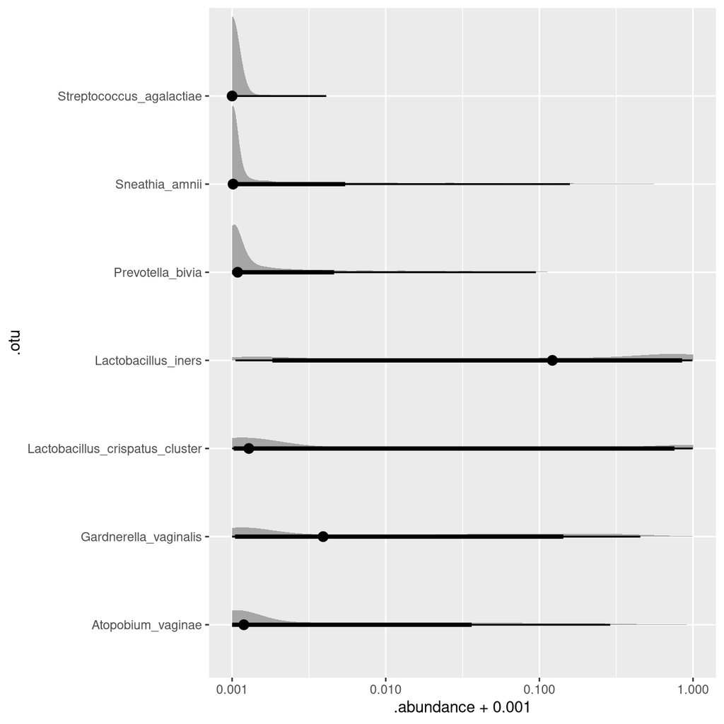

```r
ps %>%
  transform_sample_counts(~ . / sum(.)) %>%
  filter_tax_table(.otu %in% control_taxa) %>%
  as_tibble %>%
  ggplot(aes(y = .otu, x = .abundance + 1e-3)) +
  scale_x_log10() +
  ggdist::stat_halfeye()
```

## Save tables

```r
dr <- here("output", "stirrups-profiles")
dir_create(dr)
```

Before saving, let’s add a field to the tax table to denote the control taxa from @brooks2015thet.

```r
tax1 <- tax %>%
  mutate(control = otu %in% control_taxa)
tax1 %>% count(control)
```

```
## # A tibble: 2 x 2
##   control     n
##   <lgl>   <int>
## 1 FALSE     353
## 2 TRUE        7
```

Save the abundance matrix, sample data, and tax table as compressed CSV files,

```r
mat %>%
  as_tibble(rownames = "sample_name") %>%
  write_csv(path(dr, str_glue("abundance-matrix.csv.bz2")))
write_csv(sam, path(dr, str_glue("sample-data.csv.bz2")))
write_csv(tax1, path(dr, str_glue("taxonomy.csv.bz2")))
```